# What Songs Tell Us about Generation Preference on Lyrics?

## Introduction

#### In this text mining project, I would like to discover whether there is preference between different generations about words on lyrics.

- Love, time, baby, ill, day are the most common words, regardless of Region, Time and Genre
- Looked at the pattern of words usage besides those five common words
- Focused on Two Generations: Elder Generation (Before 21 Century) and Young Generation (After 21 Century)

## Question 1 Is there any difference on word usage in the lyrics of our parents and ourselves?

### Wordcloud before distinguishing between generations

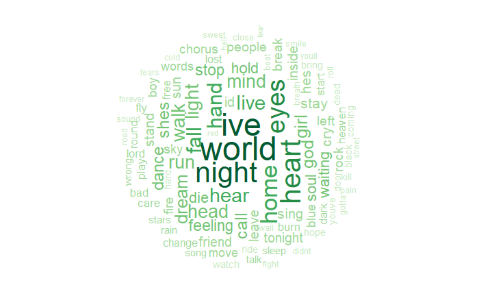

### Wordcloud of Young Generation

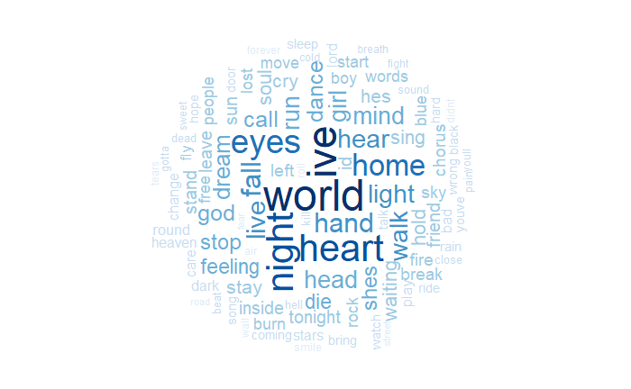

### Wordcloud of Elder Generation

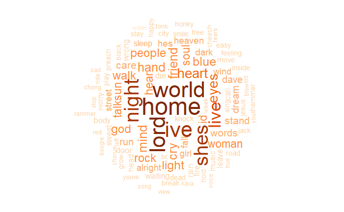

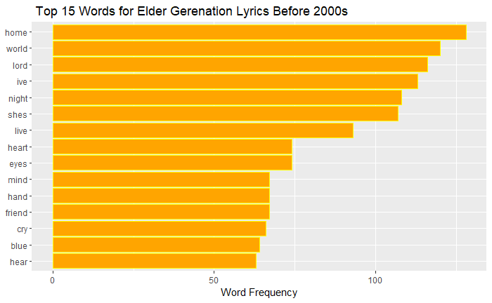

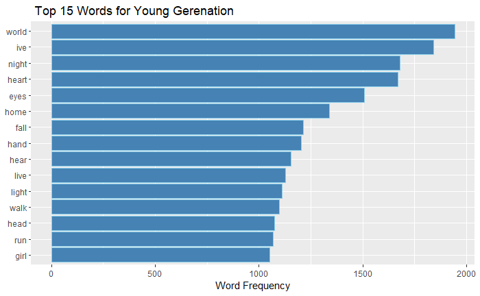

# Question 2: Do we have the different level of emontion between generations?

#### Now let’s go deeper with sentimental analysis. By 10 different sentiments of NRC lexicon, I got the proportion of each sentiment per generation. The distributions of sentiments between the two groups have a similar pattern. But the lyrics of young generations tend to be more negative than positive, whereas those of elder generations are slightly more likely to be positive than negative. In addtion, young generations seem to have more fears than elder generations.

#### Sentiment Analysis with nrc Lexicon

#### Proportional Comparison for Each Genreration

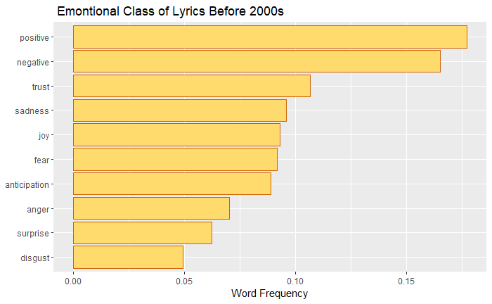

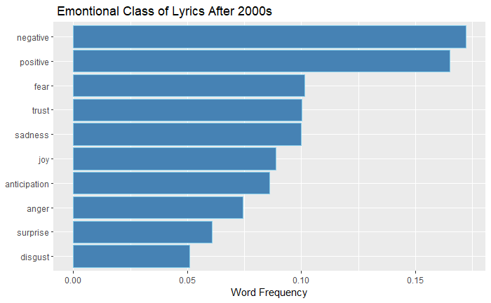

#### Sentiment Analysis with Afinn Lexicon

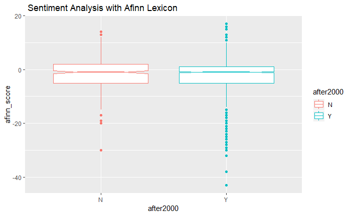

```
          Min. 1st Qu. Median      Mean 3rd Qu. Max.
elder_gen  -30      -5     -1 -1.485893       2   14
young_gen  -43      -5     -1 -2.015608       1   17
```

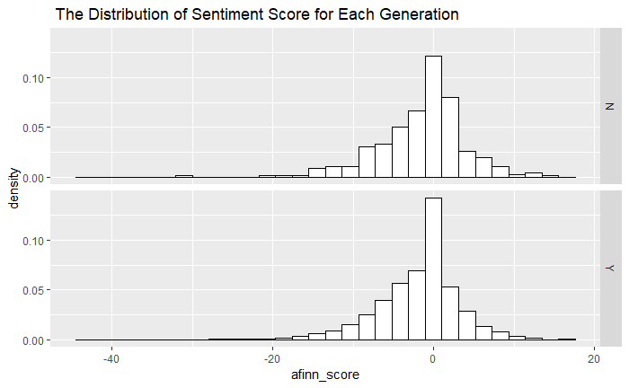

# Question 3: Can we tell which emotions are possibly from which potential sources based on lyrics for each generation group?

#### I got several words from postive and negative sentiments assigned by Bing lexison for both generations

#### Sentiment Analysis for Bing Lexison

| word | n |
| --- | --- |
| heaven | 48 |
| sweet | 40 |
| smile | 35 |
| happy | 34 |
| easy | 33 |
| free | 33 |
| shine | 24 |
| fine | 23 |
| fun | 18 |
| joy | 18 |

[output cut: 162 more lines]

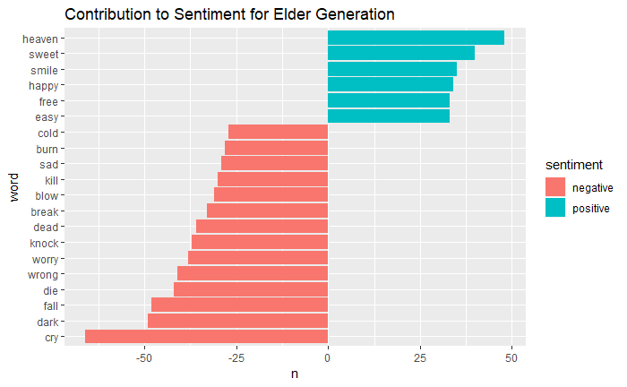

#### Key Findings:

- **Heaven** is the most frequent word they used when they feel positive.
- **Cry** is the most common word to be used when they expressed negative feelings

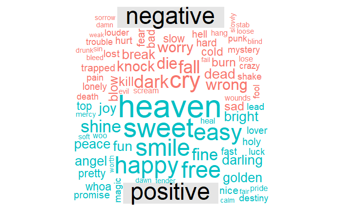

| word | n |
| --- | --- |
| free | 670 |
| heaven | 623 |
| sweet | 444 |
| smile | 421 |
| happy | 391 |
| shine | 389 |
| easy | 366 |
| angel | 339 |
| ready | 307 |
| beautiful | 281 |

[output cut: 493 more lines]

#### By contrast, young generations have a different source from postive and negative sentiments.

- **Free** is the most frequent word they used when they feel positive
- **Fall** is the most common word to be used when they expressed negative feelings
- Young generations valued freedoom heavier than their parent generations
- Young generations regarded **die**,**fall** a really negative word

[figure not shown]

```r
bing <- get_sentiments("bing")
bing_word_counts <- lyrics_data_after %>%
  inner_join(bing) %>%
  count(word, sentiment, sort = TRUE)
bing_word_counts %>%
  filter(n > 350) %>%
  mutate(n = ifelse(sentiment == "negative", -n, n)) %>%
  mutate(word = reorder(word, n)) %>%
  ggplot(aes(word, n, fill = sentiment)) +
  geom_col() +
  coord_flip() +
  labs(title = "Contribution to Sentiments before 2000s")
```

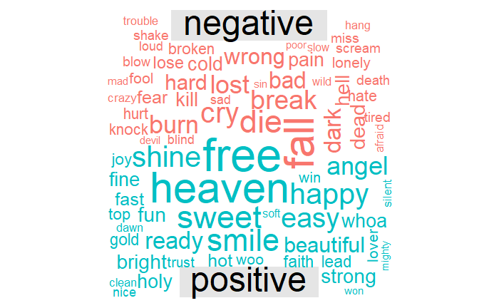

```r
library(reshape2)
lyrics_data_after %>%
  inner_join(bing) %>%
  count(word, sentiment, sort = TRUE) %>%
  acast(word ~ sentiment, value.var = "n", fill = 0) %>%
  comparison.cloud(colors = c("#F8766D", "#00BFC4"),
                   max.words = 100)
```

#### I further broke down sentiment groups to several refined emotional groups such as anticipation,joy anger,disgust,sadness,surprise,trust and fear.

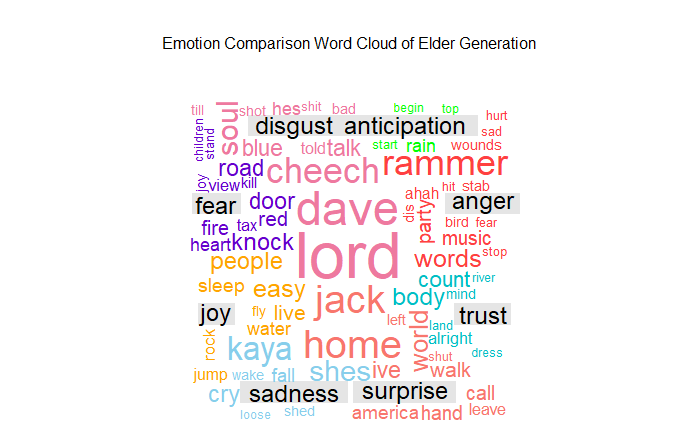

#### Key findings for Elder Generations:

- **fears** are from tax, fire, somebady knocking the door in late night
- **surprise** are from home and world
- Cry,loose can cause **sadness**
- Sleep, easy stuff make people **joy**
- Rammer, wounds, hurt make people **anger**

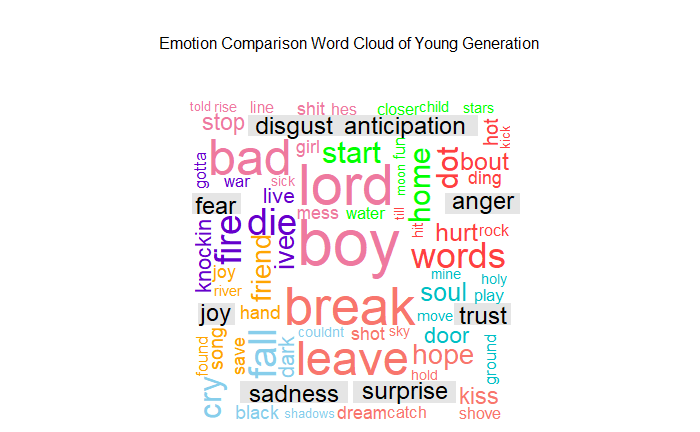

#### Key findings for Young Generations:

- **fears** are no longer from tax but now from war and death
- **surprise** are no longer from home and world, but from kiss and dream and hope.
- Cry can cause **sadness** for young generaitons, besides, shadows, dark and fall are unhapppy words from their perspectives
- Sleep, easy stuff no longer make young people **joy**, to be joy, they need to sing a song and stay with a friends.

#### In conclusion, we can conclude that there is a clear tendency of the words usage between generations and so are song lyrics. As what we have sang is what we think, what we want and what we dream of, lyrics tells us what society wants to hear.